# Lesson 10

Timothy Luna

8/23/2019

# 2B-L3 Generalized Hough Transform

## Intro

Two significant changes generalize the Hough transform:

1. Non-analytic models (lines and circles both have analytic parameters) but rather models where parameters express variation in pose or scale of some fixed but arbitrary shape (this is a historical usage.)
2. Visual code-word based features with aren’t *edges* but are instead detected templates learned from models (this is present day usage.)

## Generalized Hough Transform

A Hough transform was easy when we had a specific shape because each point knew how to vote. With an arbitrary shape how do you know how to vote?

### Training:

Build a Hough table.

- At each boundary point $(p_i)$ compute a displacement vector: $r=c-p_i$
- Measure the gradient angle $\theta$ at the boundary point.
- Store that displacement in a table indexed by $\theta$.

The idea is to create the r based off the offset and then index it by $\theta$.

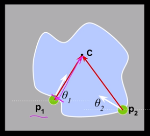

### Recognition:

- At each boundary point measure the gradient angle $\theta$ (Assuming that object orientation does not change)
- Look up all displacements in $\theta$ displacement table.
- Vote for a center at each displacement.

The idea is that the correct reference point gathers the majority of the votes.

(done by Daniel Ballard in 1980)

## Generalized Hough Transform Example

Assume we know at any point which way is inside our shape and which is outside.

All the points on the bottom have the *same* $\theta$, but each has a different displacement. At recognition all of those points will vote for *every possible point that could be the reference.* The peak indicates the likely reference point.

The same concept applies when voting for the downward facing diagonals. At runtime each diagonal element votes for each possible reference point and the peak indicates the reference!

No matter which side is doing the voting the same concept applies of using the table of the offsets indexed by the gradient to vote for the center / reference point.

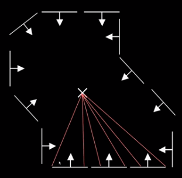

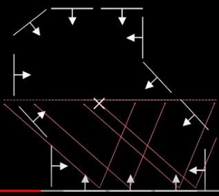

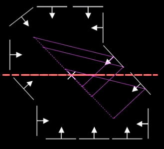

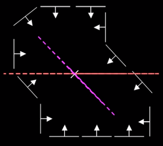

## Generalized Hough Transform Algorithm

If the orientation is known

1. For each edge point compute the gradient direction $\theta$, and retrieve the displacement vectors $r$ to vote for reference points.
2. The peak in this Hough space $(X,Y)$ is the reference point with the most suporting edges.

It is **unreasonable** to assume the orientation is known, so we can add a little something extra.

If orientation is unknown.

1. For each edge point and for each possible master $\theta^*$ compute the gradient direction $\theta$; set $\theta'=\theta-theta^*$ and for $\theta'$ retrieve displacement vectors $r'$ to vote for the reference point.
2. The peak in this Hough space $(X, Y, \theta^*)$ is the reference point with the most supporting edges.

This 3D space creates difficulties with binning!

You could do this for scale as well by simply replacing the master theta ($\theta^*$) by some master scaling factor.

## Application in Recognition

Using Hough transformed displacement vectors segued relatively recently to codeword matching (matching feature patches in images).

There is an example of a feature patch as the tires on a Jaguar. Each tire is a general ‘feature patch’ which is normally at some radius $r$ from the center point of a car. Each feature patch (tire) has two possible $\vec r$ which could locate the reference point in the image (center of the car) and when the tires are located and the two $\vec r$ join together in one location the car is identified!

## Training

Develop the ‘visual code words’; using an operator generate interest points (Many ways of finding this) of generalized features like tires, noses, etc….

Collect image patches around the interest points.

Cluster the image patches.

The centers of the clusters are now *visual code words*.